# Practical Machine Learing Week 4 Assignment/Report

Khairul Izhar Khalid

May 20, 2017

### A: INTRODUCTION, OBJECTIVE AND APPROACH:

**A1 INTRODUCTION:-**

The given data set in this assigment report, contains “Weight Lifting Exercises” (WLE) data, performed by the 6 participants (aged between 20-28 years). The data sets was recorded using wearable devices. Each participants was asked to perform 1 set of 10 repetitions of the Unilateral Dumbbell (1.25kg) Biceps Curl in 5 different fashions (“classe”). **1. Class A - Exactly according to the specification; 2. Class B - Throwing the elbows to the front; 3. Class C - Lifting the dumbbell only halfway; 4. Class D - Lowering the dumbbell only halfway; and 5. Class E - Throwing the hips to the front.**

**Note:** The given data set and the information above was originally based on a research. Citation Reference; please refer to **Section H: Reference.**

**A2 OBJECTIVE:-**

The objective of this project/assignment is to **predict** the manner in which the 6 participants did the dumbbell exercises“, leveraging on the”classe" values as the main broad category.

**A3 APPROACH:-**

The following describes the project approach for this assignment:

**1. Data Preparation -** Load related libraries and download the the data sets from information provided in the assignment, set location path and store in working directory. **2. Perform Data Exploratory and Data Cleansing -** to both data sets (training and testing) **3. Assembling Data Partition -** into the cleansed training data set - 70%|30% (exclude the clean testing data set) **4. Apply caret’s Generalized Boosted and Random Forest Function** into the both partitioned data sets and identify the accuracy level **5. The highest accuracy model is then apply to the clean testing data set to predict 20 different test cases.** The prediction results will be used for quiz submission

### B: DATA PREPARATION:

First, all the required libraries, to support our analysis and prediction are loaded (as shown below)

```r
#Loading neccessary libraries
library(ggplot2)
library(caret)
library(plyr)
library(kernlab)
library(rpart)
library(rpart.plot)
library(randomForest)
library(e1071)
```

2 types of raw data set(s) (pml-training.csv and pml-testing.csv) was provided from the following source:

1. Training Data: https://d396qusza40orc.cloudfront.net/predmachlearn/pml-training.csv
2. Test Data: https://d396qusza40orc.cloudfront.net/predmachlearn/pml-testing.csv

```r
# Assign 2 variables as raw data filenames and set path in raw data directory
trainingFilename = file.path("rawDatasets","pml-training.csv")
testingFilename = file.path("rawDatasets","pml-testing.csv")

# Assign 2 variables as raw data sets URL source
urlLink.Training <- "https://d396qusza40orc.cloudfront.net/predmachlearn/pml-training.csv"
urlLink.Testing <- "https://d396qusza40orc.cloudfront.net/predmachlearn/pml-testing.csv"

# Check file exist, else download the datasets, check directory exist, else  directory create
if (!file.exists(trainingFilename) || !file.exists(testingFilename)){
  if(!dir.exists(file.path("rawDatasets"))){
    dir.create("rawDatasets")}
    download.file(urlLink.Training, trainingFilename, method="curl")
    download.file(urlLink.Testing, testingFilename, method="curl")
}

# Reads dataset from file names, assign to 2 variables, dimension output
raw.Training <- read.csv(trainingFilename, na.strings = c("NA", ""))
raw.Testing <- read.csv(testingFilename, na.strings = c("NA", ""))
dim(raw.Training); dim(raw.Testing)
```

```
## [1] 19622   160
```

```
## [1]  20 160
```

The given raw data URL link was downloaded, into “rawdataset” working directory based on the given URL link. Data input was performed, assigned to 2 variables (raw.Training and raw.Testing). **The dimensions indicated that raw.Training = 19622 objects and 160 variables, and raw.Testing = 20 objects and 160 variables**

### C: DATA EXPLORATARY AND DATA CLEANSING:

Looking at the “AS IS”, raw data sets, we identify NA’s, DIV/0! and 7 Identifiers variables(columns) (i.e. x, “user_name”, “raw_timestamp_part1”,“raw_timestamp_part2”, “cvtd_timestamp”, “new_window”, “num_window”). Therefore, we have to removed the variables(columns) that contains values as stated above, to ensure that the data sets are properly cleansed before running the data partition process.

```r
# Cleansing "NA" column(s)
cleanse.Training <- raw.Training[, colSums(is.na(raw.Training)) == 0]
cleanse.Testing <- raw.Testing[, colSums(is.na(raw.Testing)) == 0]

# Cleansing columns 1 to 7
cleanse.Training <- cleanse.Training[, -c(1:7)]
cleanse.Testing <- cleanse.Testing[, -c(1:7)]

# Get Cleanse Data Dimensions
dim(cleanse.Training); dim(cleanse.Testing)
```

```
## [1] 19622    53
```

```
## [1] 20 53
```

### D: ASSEMBLING DATA PARTITION FOR PREDICTION MODEL:

The createDataPartition function was then applied to create 2 data partition, leveraging on “cleanse.Training” data set. **“trainSet” is allocated 70% of cleanse.Training and “testSet” is allocated 30% of cleanse.Training**

```r
#Create partition data into cleanse.Training data set, (allocate 0.7/70%)
partition.Data <-createDataPartition(y=cleanse.Training$classe, p=0.7, list = FALSE)

# assign partiondata(0.7/70%) into datapartition4.Training
trainSet <-cleanse.Training[partition.Data,]

# assign -partiondata(remaining 30%) into datapartition4.Testing
testSet <-cleanse.Training[-partition.Data,]

# Output Dimensions information
dim(trainSet); dim(testSet)
```

```
## [1] 13737    53
```

```
## [1] 5885   53
```

**After data partition: trainSet: 13737 objects; testSet: 5885 objects.** Both data partitions will be applied into Random Forest function and caret’s Generalized Boosted Model(aka gbm) for prediction models.The model with highest accuracy will be used for quiz predictions, leveraging on “cleanse.Testing” data set.

### E: GENERALIZED BOOSTED MODEL:

```r
set.seed(1969) # set seed to obtain similar results

# assign control paramaters for train environment
gbmTrainctrl <- trainControl(method = "cv", number = 5, repeats = 1)

# apply mod.gbm with gmb method
mod.gbm  <- train(classe~.,data=trainSet,method="gbm",trControl=gbmTrainctrl,verbose =FALSE)

# apply prediction on testSet dataset based on mod.gbm
predictor.gbm <- predict(mod.gbm, newdata=testSet)

# apply confusion matrix to get accuracy summary, display output
cm.gbm <- confusionMatrix(predictor.gbm, testSet$classe)
cm.gbm
```

```
## Confusion Matrix and Statistics
##
##           Reference
## Prediction    A    B    C    D    E
##          A 1655   44    0    2    1
##          B   14 1070   36    0    6
##          C    4   20  979   33   12
##          D    0    5    9  914   10
##          E    1    0    2   15 1053
##
## Overall Statistics
##
##                Accuracy : 0.9636
##                  95% CI : (0.9585, 0.9683)
##     No Information Rate : 0.2845
##     P-Value [Acc > NIR] : < 2.2e-16
##
##                   Kappa : 0.954
##  Mcnemar's Test P-Value : 5.734e-09
##
## Statistics by Class:
##
##                      Class: A Class: B Class: C Class: D Class: E
## Sensitivity            0.9886   0.9394   0.9542   0.9481   0.9732
## Specificity            0.9888   0.9882   0.9858   0.9951   0.9963
## Pos Pred Value         0.9724   0.9503   0.9342   0.9744   0.9832
## Neg Pred Value         0.9955   0.9855   0.9903   0.9899   0.9940
## Prevalence             0.2845   0.1935   0.1743   0.1638   0.1839
## Detection Rate         0.2812   0.1818   0.1664   0.1553   0.1789
## Detection Prevalence   0.2892   0.1913   0.1781   0.1594   0.1820
## Balanced Accuracy      0.9887   0.9638   0.9700   0.9716   0.9847
```

### F: RANDOM FOREST:

```r
set.seed(1970) # set seed to obtain similar results

# assign control paramaters for train environment
rfTrainctrl <- trainControl(method="cv",number=4, allowParallel=TRUE)

# mod.rf random forest
mod.rf <- randomForest(classe~.,method="class",data=trainSet,trControl= rfTrainctrl)

# apply prediction on testSet dataset based on random forest fit
predictor.rf <- predict(mod.rf,newdata=testSet)

# apply caret confusion matrix to get accuracy summary, display output
cm.rf <- confusionMatrix(predictor.rf,testSet$classe)
cm.rf
```

```
## Confusion Matrix and Statistics
##
##           Reference
## Prediction    A    B    C    D    E
##          A 1674    5    0    0    0
##          B    0 1134   10    0    0
##          C    0    0 1015   11    2
##          D    0    0    1  951    2
##          E    0    0    0    2 1078
##
## Overall Statistics
##
##                Accuracy : 0.9944
##                  95% CI : (0.9921, 0.9961)
##     No Information Rate : 0.2845
##     P-Value [Acc > NIR] : < 2.2e-16
##
##                   Kappa : 0.9929
##  Mcnemar's Test P-Value : NA
##
## Statistics by Class:
##
##                      Class: A Class: B Class: C Class: D Class: E
## Sensitivity            1.0000   0.9956   0.9893   0.9865   0.9963
## Specificity            0.9988   0.9979   0.9973   0.9994   0.9996
## Pos Pred Value         0.9970   0.9913   0.9874   0.9969   0.9981
## Neg Pred Value         1.0000   0.9989   0.9977   0.9974   0.9992
## Prevalence             0.2845   0.1935   0.1743   0.1638   0.1839
## Detection Rate         0.2845   0.1927   0.1725   0.1616   0.1832
## Detection Prevalence   0.2853   0.1944   0.1747   0.1621   0.1835
## Balanced Accuracy      0.9994   0.9968   0.9933   0.9930   0.9979
```

### G: WHICH MODEL IS APPLY TO CLEANSED TEST DATA?:

The overall accuracy percentage results shown in confusion matrix clearly indicates random forest has the highest accuracy. Therefore, **Random Forest Model will be applied into the quiz predictions**, leveraging on cleansed testing data set. The result is shown below:

```r
Quizpredictor4.cleanseTesting <- predict(mod.rf, newdata=cleanse.Testing)
Quizpredictor4.cleanseTesting
```

```
##  1  2  3  4  5  6  7  8  9 10 11 12 13 14 15 16 17 18 19 20
##  B  A  B  A  A  E  D  B  A  A  B  C  B  A  E  E  A  B  B  B
## Levels: A B C D E
```

### H: REFERENCE:

Velloso, E.; Bulling, A.; Gellersen, H.; Ugulino, W.; Fuks, H. Qualitative Activity Recognition of Weight Lifting Exercises. Proceedings of 4th International Conference in Cooperation with SIGCHI (Augmented Human ’13) . Stuttgart, Germany: ACM SIGCHI, 2013. Read more: http://groupware.les.inf.puc-rio.br/har#ixzz4hyNSlNVh

### I: APPENDIX 1:

```r
# raw training data structure
str(raw.Training)
```

[output not shown]

[output cut: 86 more lines]

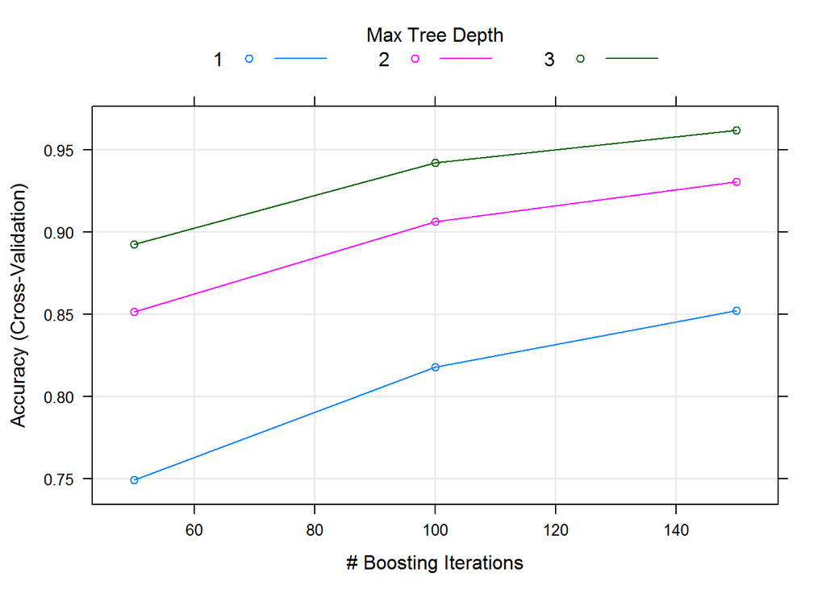

```r
# plot mod.rf and mod.gbm
plot(mod.gbm)
```

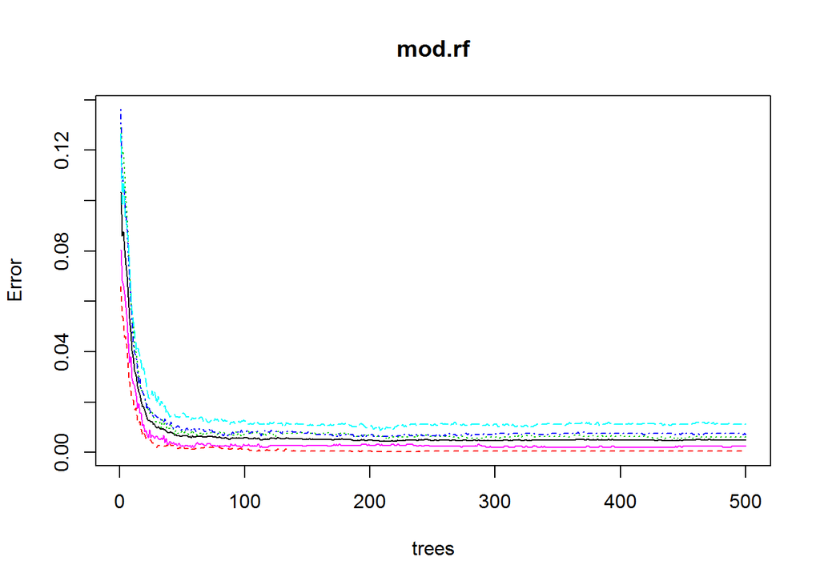

```r
plot(mod.rf)
```